# Introduction to metalite.sl

```r
library(metalite)
library(metalite.sl)
```

# Overview

metalite.sl R package designed for the analysis & reporting of subject-level analysis in clinical trials. It operates on ADaM datasets and adheres to the metalite structure. The package encompasses the following components:

**Baseline Characteristics.**

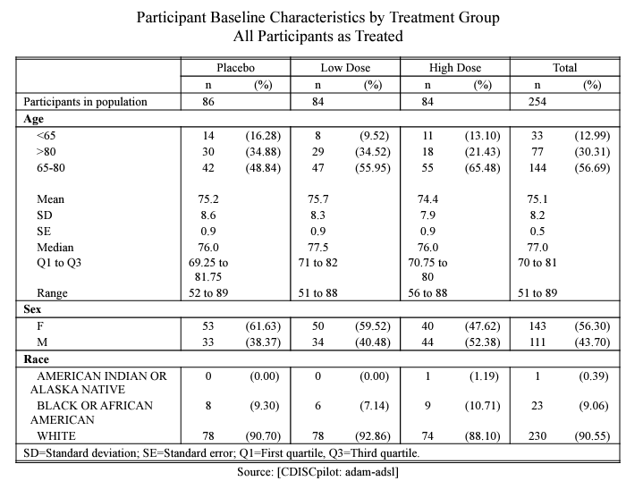

This R package offers a comprehensive software development lifecycle (SDLC) solution, encompassing activities such as definition, development, validation, and finalization of the analysis.

# Highlighted features

- Avoid duplicated input by using metadata structure.
  - For example, define analysis population once to use in all subject level analysis.
- Consistent input and output in standard functions.
- Provide workflow to add interactive features to subject-level analysis table.

# Workflow

The overall workflow includes the following steps:

1. Define metadata information using metalite R package.
2. Prepare outdata using `prepare_*()` functions.
3. Extend outdata using `extend_*()` functions (optional).
4. Format outdata using `format_*()` functions.
5. Create TLFs using `tlf_*()` functions.

For instance, we can illustrate the creation of a straightforward Baseline characteristic table as shown below.

```r
meta_sl_example() |>
  prepare_base_char(
    population = "apat",
    analysis = "base_char",
    parameter = "age;gender"
  ) |>
  format_base_char() |>
  rtf_base_char(
    source = "Source: [CDISCpilot: adam-adsl]",
    path_outdata = tempfile(fileext = ".Rdata"),
    path_outtable = tempfile(fileext = ".rtf")
  )
```

[figure not shown]

An example for interactive baseline characteristic table:

```r
react_base_char(
  metadata_sl = meta_sl_example(),
  metadata_ae = metalite.ae::meta_ae_example(),
  population = "apat",
  observation = "wk12",
  display_total = TRUE,
  sl_parameter = "age;race",
  ae_subgroup = c("age", "race"),
  ae_specific = "rel",
  width = 1200
)
```

|  | n | (%) | n | (%) | n | (%) | n | (%) |  |
| --- | --- | --- | --- | --- | --- | --- | --- | --- | --- |
| Participants in population | 86 | NA | 84 | NA | 84 | NA | 254 | NA | Participants in population |
| 65-80 | 42 | (48.84) | 47 | (55.95) | 55 | (65.48) | 144 | (56.69) | Age (years) |
| <65 | 14 | (16.28) | 8 | (9.52) | 11 | (13.10) | 33 | (12.99) | Age (years) |
| >80 | 30 | (34.88) | 29 | (34.52) | 18 | (21.43) | 77 | (30.31) | Age (years) |
| NA | NA | NA | NA | NA | NA | NA | NA | NA | Age (years) |
| Mean | 75.2 | NA | 75.7 | NA | 74.4 | NA | 75.1 | NA | Age (years) |
| SD | 8.6 | NA | 8.3 | NA | 7.9 | NA | 8.2 | NA | Age (years) |
| SE | 0.9 | NA | 0.9 | NA | 0.9 | NA | 0.5 | NA | Age (years) |
| Median | 76.0 | NA | 77.5 | NA | 76.0 | NA | 77.0 | NA | Age (years) |
| Q1 to Q3 | 69.25 to 81.75 | NA | 71 to 82 | NA | 70.75 to 80 | NA | 70 to 81 | NA | Age (years) |

[output cut: 4 more lines]

Additional examples and tutorials can be found on the [package website](https://merck.github.io/metalite.sl/articles/), offering further guidance and illustrations.

## Input

To implement the workflow in metalite.sl, it is necessary to establish a metadata structure using the metalite R package. For detailed instructions, please consult the [metalite tutorial](https://merck.github.io/metalite/articles/metalite.html) and refer to the source code of the function [`meta_sl_example()`](https://github.com/Merck/metalite.sl/blob/main/R/meta_sl_example.R).